# Social network analysis with R: modeling

Alex Hanna, Pablo Barbera, Dan Cervone

January 21, 2016

Up to this point, we have focused on describing networks, both visually and numerically. Now we turn to trying to **explain** how networks emerge: what are the mechanisms that explain the structure of the observed networks?

We’ll continue with the example of the Twitter network of Congress. Our goal will be to find the micro-mechanisms that explain following decisions and thus network formation.

One of the most basic notions governing network formation is **homophily**, that is, the propensity of individuals to [cluster along common traits](https://en.wikipedia.org/wiki/Homophily), such as agen, gender, class, etc.

We can measure the extent to which a network is homophilic along a specific variable by computing the **assortativity index**. Positive values indicate a positive propensity; negative values indicate negative propensity.

```r
assortativity_degree(g, directed=FALSE)
```

```
## [1] -0.1027231
```

```r
assortativity(g, log(V(g)$followers_count), directed=FALSE)
```

```
## [1] 0.1064822
```

```r
assortativity_nominal(g, factor(V(g)$chamber))
```

```
## [1] 0.3989669
```

```r
assortativity_nominal(g, factor(V(g)$party))
```

```
## [1] 0.6528812
```

```r
assortativity_nominal(g, factor(V(g)$gender))
```

```
## [1] 0.0830673
```

```r
prop.table(table(V(g)$gender, V(g)$party), margin=2)
```

```
##
##       Democrat Independent Republican
##   F 0.33482143  0.00000000 0.09688581
##   M 0.66517857  1.00000000 0.90311419
```

To try to address these limitations, we can rely on **exponential random graph models**. We will not get into the details, but here’s a general intuition of how these models work:

- These models start from your observed network. It is considered a realization of many possible networks with the same number of nodes and edges.
- The goal is to learn the mechanisms that explain how you get to this specific network, e.g. homophily, reciprocity, transitivity… Each of these mechanisms is considered a parameter in the model.
- Assuming these mechanisms, what is the likelihood of arriving to the network you observe? From the probability distribution of all possible networks based on the parameter space, what is the probability of observing this particular one?
- The goal is to estimate the parameters that best match the observed network using MCMC methods.

For a great introduction to ERGMs, see [Robins et al (2007) _An introduction to exponential random graph (p*) models for social networks_, **Social Networks**](http://ptrckprry.com/course/ssd/Robi07a.pdf).

We can estimate these models with the `ergm` package in R. Unfortunately, `ergm` works with object in `network` format (not `igraph`), so we will need to convert first between packages using the `intergraph` package.

```r
library(intergraph)
library(network)
net <- asNetwork(g)
net
```

```
##  Network attributes:
##   vertices = 514
##   directed = TRUE
##   hyper = FALSE
##   loops = FALSE
##   multiple = FALSE
##   bipartite = FALSE
##   total edges= 61766
##     missing edges= 0
##     non-missing edges= 61766
##
##  Vertex attribute names:
##     bioid chamber followers_count gender party twitter vertex.names
##
##  Edge attribute names not shown
```

(We could also create the object directly as a `network` object, but converting from igraph is easier.)

What parameters can we add to the model?

- **edges** = number of edges in the network. It’s equivalent to a constant in a regression. Given that this network is relatively sparse, the parameter is negative, which means that the probability of observing any given edge is low. In fact, the estimated parameter in this baseline model is equal to the log of the odds of observing any edge.

```r
library(ergm)
reg1 <- ergm(net ~ edges)
```

```
## Evaluating log-likelihood at the estimate.
```

```r
summary(reg1)
```

```
##
## ==========================
## Summary of model fit
## ==========================
##
## Formula:   net ~ edges
##
## Iterations:  5 out of 20
##
## Monte Carlo MLE Results:
##        Estimate Std. Error MCMC % p-value
## edges -1.184499   0.004598      0  <1e-04 ***
## ---
## Signif. codes:  0 '***' 0.001 '**' 0.01 '*' 0.05 '.' 0.1 ' ' 1
##
##      Null Deviance: 365541  on 263682  degrees of freedom
##  Residual Deviance: 287073  on 263681  degrees of freedom
##
## AIC: 287075    BIC: 287085    (Smaller is better.)
```

```r
#   no. of edges / ( no. of potential edges - no. of existing edges)
log(length(E(g)) / ( length(V(g))*(length(V(g))-1) - length(E(g))))
```

```
## [1] -1.184499
```

- **mutual** = number of mutual dyads. This parameter captures reciprocity as a mechanism for tie formation. If positive, it means reciprocity is more common than expected given the baseline probability of any two nodes being connected, holding the number of edges constant. In the case below, the positive coefficient means that if you see an edge from `i` to `j`, then you are exp(2.04)=7.76 times more likely to see an edge from `j` to `i` as well.

```r
reg2 <- ergm(net ~ edges + mutual)
```

```
## Starting maximum likelihood estimation via MCMLE:
## Iteration 1 of at most 20:
## The log-likelihood improved by 0.2169
## Step length converged once. Increasing MCMC sample size.
## Iteration 2 of at most 20:
## The log-likelihood improved by 0.03937
## Step length converged twice. Stopping.
## Evaluating log-likelihood at the estimate. Using 20 bridges: 1 2 3 4 5 6 7 8 9 10 11 12 13 14 15 16 17 18 19 20 .
##
## This model was fit using MCMC.  To examine model diagnostics and check for degeneracy, use the mcmc.diagnostics() function.
```

```r
summary(reg2)
```

```
##
## ==========================
## Summary of model fit
## ==========================
##
## Formula:   net ~ edges + mutual
##
## Iterations:  2 out of 20
##
## Monte Carlo MLE Results:
##         Estimate Std. Error MCMC % p-value
## edges  -1.838748   0.007109      2  <1e-04 ***
## mutual  2.046271   0.016400      2  <1e-04 ***
## ---
## Signif. codes:  0 '***' 0.001 '**' 0.01 '*' 0.05 '.' 0.1 ' ' 1
##
##      Null Deviance: 365541  on 263682  degrees of freedom
##  Residual Deviance: 273445  on 263680  degrees of freedom
##
## AIC: 273449    BIC: 273470    (Smaller is better.)
```

```r
reg3 <- ergm(net ~ edges + mutual + nodematch("party"))
```

```
## Starting maximum likelihood estimation via MCMLE:
## Iteration 1 of at most 20:
## The log-likelihood improved by 2.126
## Step length converged once. Increasing MCMC sample size.
## Iteration 2 of at most 20:
## The log-likelihood improved by 5.513
## Step length converged twice. Stopping.
## Evaluating log-likelihood at the estimate. Using 20 bridges: 1 2 3 4 5 6 7 8 9 10 11 12 13 14 15 16 17 18 19 20 .
##
## This model was fit using MCMC.  To examine model diagnostics and check for degeneracy, use the mcmc.diagnostics() function.
```

```r
summary(reg3)
```

```
##
## ==========================
## Summary of model fit
## ==========================
##
## Formula:   net ~ edges + mutual + nodematch("party")
##
## Iterations:  2 out of 20
##
## Monte Carlo MLE Results:
##                 Estimate Std. Error MCMC % p-value
## edges           -2.66677    0.01235      2  <1e-04 ***
## mutual           1.59545    0.01671      2  <1e-04 ***
## nodematch.party  1.52307    0.01228      3  <1e-04 ***
## ---
## Signif. codes:  0 '***' 0.001 '**' 0.01 '*' 0.05 '.' 0.1 ' ' 1
##
##      Null Deviance: 365541  on 263682  degrees of freedom
##  Residual Deviance: 243715  on 263679  degrees of freedom
##
## AIC: 243721    BIC: 243752    (Smaller is better.)
```

- **nodecov** and **nodefactor** = measure whether individuals with high values on a variable or with a specific value on a factor variable are more likely to follow or to be followed.
- **absdiff** = measures whether individuals with similar values along a continuous variable are more likely to have an edge between them (in either direction).

```r
reg4 <- ergm(net ~ edges + mutual + nodefactor("chamber") +
               absdiff("followers_count") + nodematch("party") +
               nodematch("chamber") + nodematch("gender"))
```

[output not shown]

```
## MCMLE estimation did not converge after 20 iterations. The estimated coefficients may not be accurate. Estimation may be resumed by passing the coefficients as initial values; see 'init' under ?control.ergm for details.
```

```
## Evaluating log-likelihood at the estimate. Using 20 bridges: 1 2 3 4 5 6 7 8 9 10 11 12 13 14 15 16 17 18 19 20 .
##
## This model was fit using MCMC.  To examine model diagnostics and check for degeneracy, use the mcmc.diagnostics() function.
```

```r
summary(reg4)
```

```
##
## ==========================
## Summary of model fit
## ==========================
##
## Formula:   net ~ edges + mutual + nodefactor("chamber") + absdiff("followers_count") +
##     nodematch("party") + nodematch("chamber") + nodematch("gender")
##
## Iterations:  20 out of 20
##
## Monte Carlo MLE Results:
##                           Estimate Std. Error MCMC % p-value
## edges                   -3.784e+00  3.963e-02      3  <1e-04 ***
## mutual                   1.407e+00  2.413e-02      4  <1e-04 ***
## nodefactor.chamber.sen   4.263e-01  2.078e-02      3  <1e-04 ***
## absdiff.followers_count  3.312e-07  7.568e-08      2  <1e-04 ***
## nodematch.party          1.679e+00  2.197e-02      3  <1e-04 ***
## nodematch.chamber        1.414e+00  3.250e-02      3  <1e-04 ***
## nodematch.gender        -1.990e-01  2.792e-02      2  <1e-04 ***
## ---
## Signif. codes:  0 '***' 0.001 '**' 0.01 '*' 0.05 '.' 0.1 ' ' 1
##
##      Null Deviance: 365541  on 263682  degrees of freedom
##  Residual Deviance: 234885  on 263675  degrees of freedom
##
## AIC: 234899    BIC: 234972    (Smaller is better.)
```

One practical issues with ERGMs is that when you add multiple variables, the MCMC chains often have convergence issues. Sometimes just running these for more iterations and increasing the thinning parameter will fix this. Sadly, very often it’s more difficult than that…

```r
mcmc.diagnostics(reg2)
```

```
## Sample statistics summary:
##
## Iterations = 16384:4209664
## Thinning interval = 1024
## Number of chains = 1
## Sample size per chain = 4096
##
## 1. Empirical mean and standard deviation for each variable,
##    plus standard error of the mean:
##
##          Mean    SD Naive SE Time-series SE
## edges   -3.71 286.2    4.473          97.87
## mutual -18.85 124.5    1.945          46.19
##
## 2. Quantiles for each variable:
##
##        2.5%  25% 50% 75% 97.5%
## edges  -598 -147  12 187 541.6
## mutual -282  -77 -15  49 262.0
##
##
## Sample statistics cross-correlations:
##            edges    mutual
## edges  1.0000000 0.8659149
## mutual 0.8659149 1.0000000
##
## Sample statistics auto-correlation:
## Chain 1
##              edges    mutual
## Lag 0    1.0000000 1.0000000
## Lag 1024 0.9958309 0.9964598
## Lag 2048 0.9917826 0.9929906
## Lag 3072 0.9877094 0.9896479
## Lag 4096 0.9836664 0.9864207
## Lag 5120 0.9798772 0.9833327
##
## Sample statistics burn-in diagnostic (Geweke):
## Chain 1
##
## Fraction in 1st window = 0.1
## Fraction in 2nd window = 0.5
##
##  edges mutual
## -1.740 -1.537
##
## Individual P-values (lower = worse):
##      edges     mutual
## 0.08189141 0.12422391
## Joint P-value (lower = worse):  0.3622014 .
```

```
## Package latticeExtra is not installed. Falling back on coda's default MCMC diagnostic plots.
```

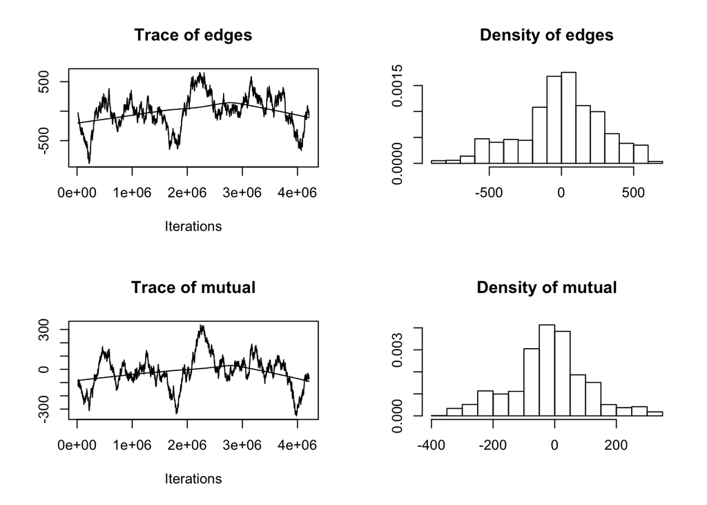

[output not shown]

Another way to check the results of the model is to simulate networks assuming the estimated parameters and compare their degree distribution to the observed indegree distribution. (Warning: running the code below will take a while!)

```r
sims <- simulate(reg2, nsim=10)
summary(sims)
reggof <- gof(reg2 ~ idegree)
plot(reggof)
```

[output not shown]